# Project_Clustering_Lentz

```python
import pandas as pd
import numpy as np
from matplotlib import pyplot as plt
%matplotlib inline
import seaborn as sns
import warnings
warnings.filterwarnings('ignore')
```

```python
pip install xlrd
```

```
     |████████████████████████████████| 103 kB 2.3 MB/s eta 0:00:01
```

```python
data = pd.read_excel("Credit Card Customer Data.xlsx")
data.head()
```

|  | Sl_No | Customer Key | Avg_Credit_Limit | Total_Credit_Cards | Total_visits_bank | Total_visits_online | Total_calls_made |
| --- | --- | --- | --- | --- | --- | --- | --- |
| 0 | 1 | 87073 | 100000 | 2 | 1 | 1 | 0 |
| 1 | 2 | 38414 | 50000 | 3 | 0 | 10 | 9 |
| 2 | 3 | 17341 | 50000 | 7 | 1 | 3 | 4 |
| 3 | 4 | 40496 | 30000 | 5 | 1 | 1 | 4 |
| 4 | 5 | 47437 | 100000 | 6 | 0 | 12 | 3 |

# 1. Univariate Analysis

```python
data.shape
```

```
(660, 7)
```

```python
data.describe()
```

|  | Sl_No | Customer Key | Avg_Credit_Limit | Total_Credit_Cards | Total_visits_bank | Total_visits_online | Total_calls_made |
| --- | --- | --- | --- | --- | --- | --- | --- |
| count | 660.000000 | 660.000000 | 660.000000 | 660.000000 | 660.000000 | 660.000000 | 660.000000 |
| mean | 330.500000 | 55141.443939 | 34574.242424 | 4.706061 | 2.403030 | 2.606061 | 3.583333 |
| std | 190.669872 | 25627.772200 | 37625.487804 | 2.167835 | 1.631813 | 2.935724 | 2.865317 |
| min | 1.000000 | 11265.000000 | 3000.000000 | 1.000000 | 0.000000 | 0.000000 | 0.000000 |
| 25% | 165.750000 | 33825.250000 | 10000.000000 | 3.000000 | 1.000000 | 1.000000 | 1.000000 |
| 50% | 330.500000 | 53874.500000 | 18000.000000 | 5.000000 | 2.000000 | 2.000000 | 3.000000 |
| 75% | 495.250000 | 77202.500000 | 48000.000000 | 6.000000 | 4.000000 | 4.000000 | 5.000000 |
| max | 660.000000 | 99843.000000 | 200000.000000 | 10.000000 | 5.000000 | 15.000000 | 10.000000 |

### Initial analysis:

I can already tell that the ranges from field to field vary a lot. The standard deviation is very large for some and very small for others. I will most likely needto standardize the scale somewhere below before I create a model off this data.

```python
data.isnull().sum()
```

```
Sl_No                  0
Customer Key           0
Avg_Credit_Limit       0
Total_Credit_Cards     0
Total_visits_bank      0
Total_visits_online    0
Total_calls_made       0
dtype: int64
```

```python
data.nunique()
```

```
Sl_No                  660
Customer Key           655
Avg_Credit_Limit       110
Total_Credit_Cards      10
Total_visits_bank        6
Total_visits_online     16
Total_calls_made        11
dtype: int64
```

### Something to note:

Its interesting that there are only 655 unique customer keys and not 660 which is the number of rows. This means there are multiple records for the same customer as this key should most likely be unique.

```
array([[<matplotlib.axes._subplots.AxesSubplot object at 0x1342b7b10>,
      dtype=object)
```

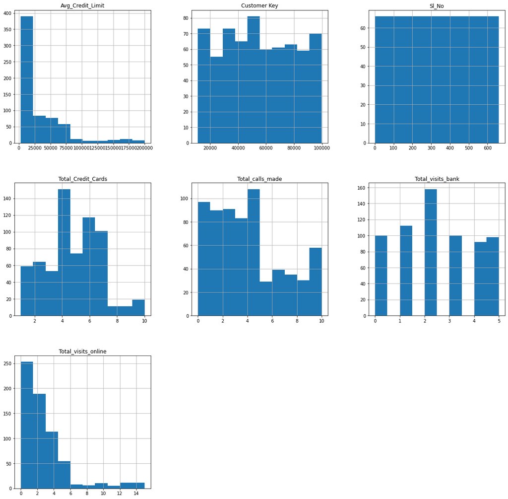

```python
data.hist( figsize=[20,20], bins=10)
```

```python
#Lets remove the columns that only indicate a customer key or
data2 = data[["Avg_Credit_Limit","Total_Credit_Cards","Total_visits_bank", "Total_visits_online","Total_calls_made"]]
```

```python
from scipy.stats import zscore

data2Scaled = data2.apply(zscore)
data2Scaled.head()
```

|  | Avg_Credit_Limit | Total_Credit_Cards | Total_visits_bank | Total_visits_online | Total_calls_made |
| --- | --- | --- | --- | --- | --- |
| 0 | 1.740187 | -1.249225 | -0.860451 | -0.547490 | -1.251537 |
| 1 | 0.410293 | -0.787585 | -1.473731 | 2.520519 | 1.891859 |
| 2 | 0.410293 | 1.058973 | -0.860451 | 0.134290 | 0.145528 |
| 3 | -0.121665 | 0.135694 | -0.860451 | -0.547490 | 0.145528 |
| 4 | 1.740187 | 0.597334 | -1.473731 | 3.202298 | -0.203739 |

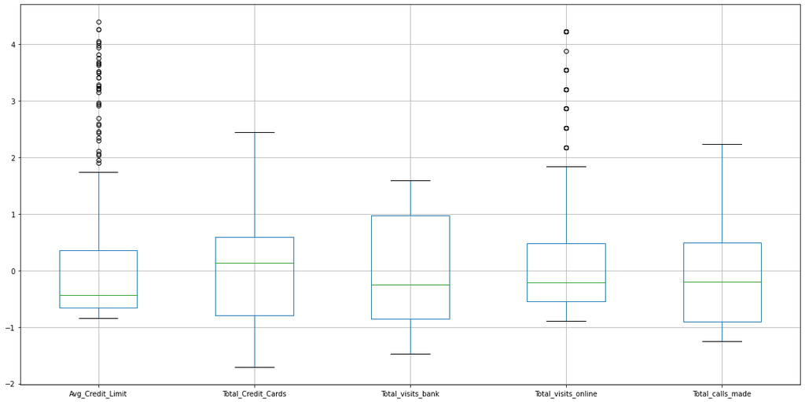

```python
plt.figure(figsize=(20,10))
data2Scaled.boxplot()
```

# 1 cont - 2. Bivariate Analysis and Plot Analysis

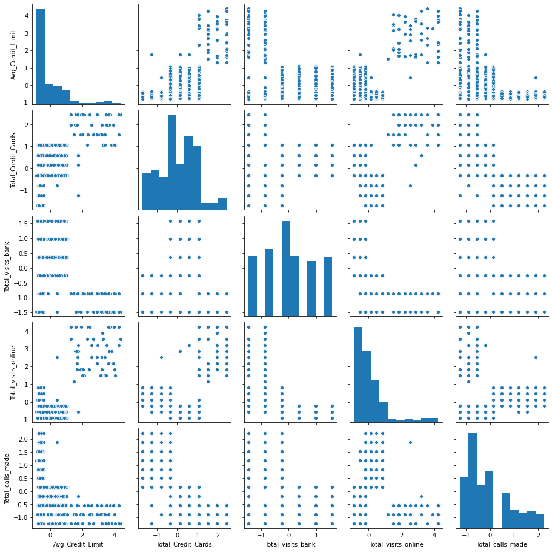

```python
sns.pairplot(data2Scaled)
```

### NOTE:

The dataframes data2 and data2Scaled should look the same as a pairplot despite the scaling as this is simply showing correlation between the columns. As proof, below is the data2 pairplot which shows the same non-scaled correlations as the charts above.

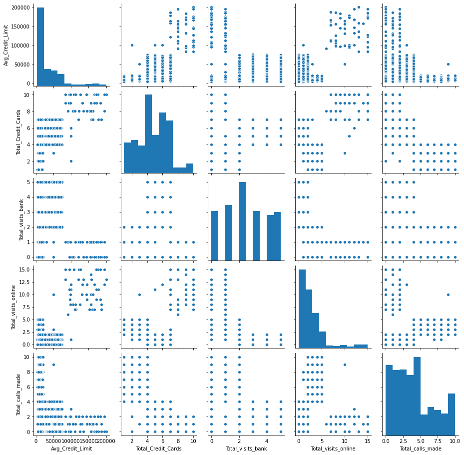

```python
sns.pairplot(data2)
```

```python
data2.corr()
```

|  | Avg_Credit_Limit | Total_Credit_Cards | Total_visits_bank | Total_visits_online | Total_calls_made |
| --- | --- | --- | --- | --- | --- |
| Avg_Credit_Limit | 1.000000 | 0.608860 | -0.100312 | 0.551385 | -0.414352 |
| Total_Credit_Cards | 0.608860 | 1.000000 | 0.315796 | 0.167758 | -0.651251 |
| Total_visits_bank | -0.100312 | 0.315796 | 1.000000 | -0.551861 | -0.506016 |
| Total_visits_online | 0.551385 | 0.167758 | -0.551861 | 1.000000 | 0.127299 |
| Total_calls_made | -0.414352 | -0.651251 | -0.506016 | 0.127299 | 1.000000 |

```python
data2Scaled.corr()
```

|  | Avg_Credit_Limit | Total_Credit_Cards | Total_visits_bank | Total_visits_online | Total_calls_made |
| --- | --- | --- | --- | --- | --- |
| Avg_Credit_Limit | 1.000000 | 0.608860 | -0.100312 | 0.551385 | -0.414352 |
| Total_Credit_Cards | 0.608860 | 1.000000 | 0.315796 | 0.167758 | -0.651251 |
| Total_visits_bank | -0.100312 | 0.315796 | 1.000000 | -0.551861 | -0.506016 |
| Total_visits_online | 0.551385 | 0.167758 | -0.551861 | 1.000000 | 0.127299 |
| Total_calls_made | -0.414352 | -0.651251 | -0.506016 | 0.127299 | 1.000000 |

# 3. KMeans Clustering

## Fit the model to the scaled data

## KMeans

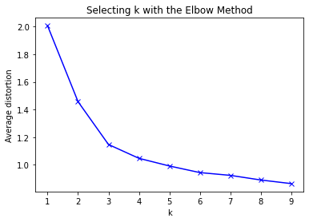

```python
from sklearn.cluster import KMeans
from scipy.spatial.distance import cdist
clusters=range(1,10)
meanDistortions=[]

for k in clusters:
    model=KMeans(n_clusters=k)
    model.fit(data2Scaled)
    prediction=model.predict(data2Scaled)
    meanDistortions.append(sum(np.min(cdist(data2Scaled, model.cluster_centers_, 'euclidean'), axis=1)) / data2Scaled.shape[0])


plt.plot(clusters, meanDistortions, 'bx-')
plt.xlabel('k')
plt.ylabel('Average distortion')
plt.title('Selecting k with the Elbow Method')
```

### Elbow analysis:

Thankfully its fairly clear to see in the plot above that we should choose either 3 or 4 but that after 4 there is little to gain by increasing the number of clusters. What this plot shows is which amount of clusters will give us the least average distance between all the points assigned to that cluster and the centroid. This is a way of testing how well a model performed on unsupervised learning technicques since we do not have a label to actually grade them on.

```python
# Let us first start with K = 4
final_model=KMeans(4)
final_model.fit(data2Scaled)
prediction=final_model.predict(data2Scaled)

#Append the prediction to the regular data and the scaled data
data["GROUP"] = prediction
data2Scaled["GROUP"] = prediction
print("Groups Assigned : \n")
data.head()
```

```
Groups Assigned :
```

|  | Sl_No | Customer Key | Avg_Credit_Limit | Total_Credit_Cards | Total_visits_bank | Total_visits_online | Total_calls_made | GROUP |
| --- | --- | --- | --- | --- | --- | --- | --- | --- |
| 0 | 1 | 87073 | 100000 | 2 | 1 | 1 | 0 | 2 |
| 1 | 2 | 38414 | 50000 | 3 | 0 | 10 | 9 | 1 |
| 2 | 3 | 17341 | 50000 | 7 | 1 | 3 | 4 | 2 |
| 3 | 4 | 40496 | 30000 | 5 | 1 | 1 | 4 | 2 |
| 4 | 5 | 47437 | 100000 | 6 | 0 | 12 | 3 | 0 |

```python
dataGrouped = data.groupby(['GROUP'])
dataGrouped.mean()
```

| GROUP | Sl_No | Customer Key | Avg_Credit_Limit | Total_Credit_Cards | Total_visits_bank | Total_visits_online | Total_calls_made |
| --- | --- | --- | --- | --- | --- | --- | --- |
| 0 | 611.280000 | 56708.760000 | 141040.000000 | 8.740000 | 0.600000 | 10.900000 | 1.080000 |
| 1 | 117.805430 | 55257.135747 | 12167.420814 | 2.393665 | 0.927602 | 3.574661 | 6.923077 |
| 2 | 415.135678 | 54071.849246 | 35904.522613 | 5.522613 | 2.477387 | 0.969849 | 2.075377 |
| 3 | 415.363158 | 55714.684211 | 31226.315789 | 5.478947 | 4.515789 | 1.010526 | 1.936842 |

```
array([[<matplotlib.axes._subplots.AxesSubplot object at 0x144a84950>,
      dtype=object)
```

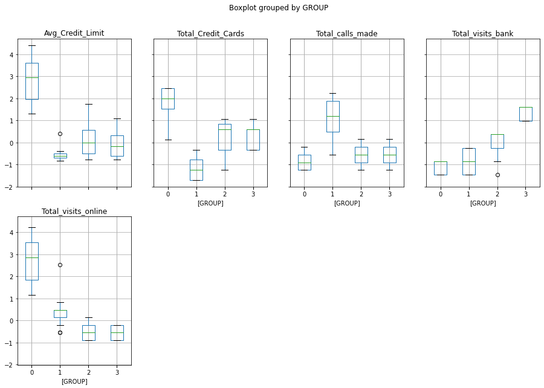

```python
data2Scaled.boxplot(by='GROUP', layout = (2,4),figsize=(15,10))
```

### Boxplot analysis:

You can tell that there isn't a huge difference between group 3 and 4 which is why it would be appropriate to also choose three clusters. There is a lot of values overlapping between group 3 and 4. The only real differentiator would be total_visits_bank which does not overlap.

# 4. Hierarchical Custering

### 4a. LINKAGE = "ward"

```python
from scipy.cluster.hierarchy import dendrogram, linkage
Z = linkage(data2Scaled, 'ward', metric='euclidean')
Z.shape
```

```
(659, 4)
```

```python
Z
```

```
array([[ 464.        ,  497.        ,    0.        ,    2.        ],
       [ 425.        ,  455.        ,    0.        ,    2.        ],
       [ 250.        ,  361.        ,    0.        ,    2.        ],
       ...,
       [1313.        , 1314.        ,   22.29479156,  388.        ],
       [1312.        , 1315.        ,   50.90830328,  272.        ],
       [1316.        , 1317.        ,   55.81353541,  660.        ]])
```

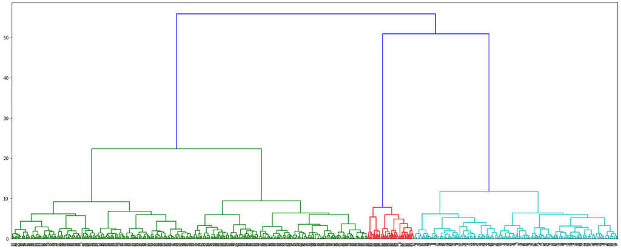

```python
plt.figure(figsize=(25, 10))
dendrogram(Z)
plt.show()
```

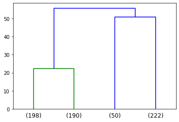

```python
dendrogram(
    Z,
    truncate_mode='lastp',  # show only the last p merged clusters
    p=4,  # show only the last p merged clusters
)
plt.show()
```

```python
from scipy.cluster.hierarchy import fcluster

max_d =50
clusters = fcluster(Z, max_d, criterion='distance')
clusters
```

```
array([1, 3, 1, 1, 2, 3, 2, 3, 3, 3, 3, 3, 3, 3, 3, 3, 3, 3, 3, 3, 3, 3,
       3, 3, 3, 3, 3, 3, 3, 3, 3, 3, 3, 3, 3, 3, 3, 3, 3, 3, 3, 3, 1, 3,
       3, 3, 3, 3, 3, 3, 3, 3, 3, 3, 3, 3, 3, 3, 3, 3, 3, 3, 3, 3, 3, 3,
       3, 3, 3, 3, 3, 3, 3, 3, 3, 3, 3, 3, 3, 3, 3, 3, 3, 3, 3, 3, 3, 3,
       3, 3, 3, 3, 3, 3, 3, 3, 3, 3, 3, 3, 3, 3, 3, 3, 3, 3, 3, 3, 3, 3,
       3, 3, 3, 3, 3, 3, 3, 3, 3, 3, 3, 3, 3, 3, 3, 3, 3, 3, 3, 3, 3, 3,
       3, 3, 3, 3, 3, 3, 3, 3, 3, 3, 3, 3, 3, 3, 3, 3, 3, 3, 3, 3, 3, 3,
       3, 3, 3, 3, 3, 3, 3, 3, 3, 3, 3, 3, 3, 3, 3, 3, 3, 3, 3, 3, 3, 3,
       3, 3, 3, 3, 3, 3, 3, 3, 3, 3, 3, 3, 3, 3, 3, 3, 3, 3, 3, 3, 3, 3,
       3, 3, 3, 3, 3, 3, 3, 3, 3, 3, 3, 3, 3, 3, 3, 3, 3, 3, 3, 3, 3, 3,
       3, 3, 3, 3, 3, 3, 3, 3, 1, 1, 1, 1, 1, 1, 1, 1, 1, 1, 1, 1, 1, 1,
       1, 1, 1, 1, 1, 1, 1, 1, 1, 1, 1, 1, 1, 1, 1, 1, 1, 1, 1, 1, 1, 1,
       1, 1, 1, 1, 1, 1, 1, 1, 1, 1, 1, 1, 1, 1, 1, 1, 1, 1, 1, 1, 1, 1,
       1, 1, 1, 1, 1, 1, 1, 1, 1, 1, 1, 1, 1, 1, 1, 1, 1, 1, 1, 1, 1, 1,
       1, 1, 1, 1, 1, 1, 1, 1, 1, 1, 1, 1, 1, 1, 1, 1, 1, 1, 1, 1, 1, 1,
```

[output cut: 16 more lines]

```python
#Append the clusters to the regular data and the scaled data
data["GROUP_hier"] = clusters
data2Scaled["GROUP_hier"] = clusters
print("Groups Assigned : \n")
data.head()
```

```
Groups Assigned :
```

|  | Sl_No | Customer Key | Avg_Credit_Limit | Total_Credit_Cards | Total_visits_bank | Total_visits_online | Total_calls_made | GROUP | GROUP_hier |
| --- | --- | --- | --- | --- | --- | --- | --- | --- | --- |
| 0 | 1 | 87073 | 100000 | 2 | 1 | 1 | 0 | 2 | 1 |
| 1 | 2 | 38414 | 50000 | 3 | 0 | 10 | 9 | 1 | 3 |
| 2 | 3 | 17341 | 50000 | 7 | 1 | 3 | 4 | 2 | 1 |
| 3 | 4 | 40496 | 30000 | 5 | 1 | 1 | 4 | 2 | 1 |
| 4 | 5 | 47437 | 100000 | 6 | 0 | 12 | 3 | 0 | 2 |

```python
dataGrouped_hier = data.drop(columns=['GROUP']).groupby(['GROUP_hier'])
dataGrouped_hier.mean()
```

| GROUP_hier | Sl_No | Customer Key | Avg_Credit_Limit | Total_Credit_Cards | Total_visits_bank | Total_visits_online | Total_calls_made |
| --- | --- | --- | --- | --- | --- | --- | --- |
| 1 | 416.296392 | 54919.360825 | 33667.525773 | 5.507732 | 3.481959 | 0.989691 | 2.010309 |
| 2 | 611.280000 | 56708.760000 | 141040.000000 | 8.740000 | 0.600000 | 10.900000 | 1.080000 |
| 3 | 117.310811 | 55176.590090 | 12180.180180 | 2.396396 | 0.923423 | 3.563063 | 6.896396 |

```
array([[<matplotlib.axes._subplots.AxesSubplot object at 0x1452fbd90>,
      dtype=object)
```

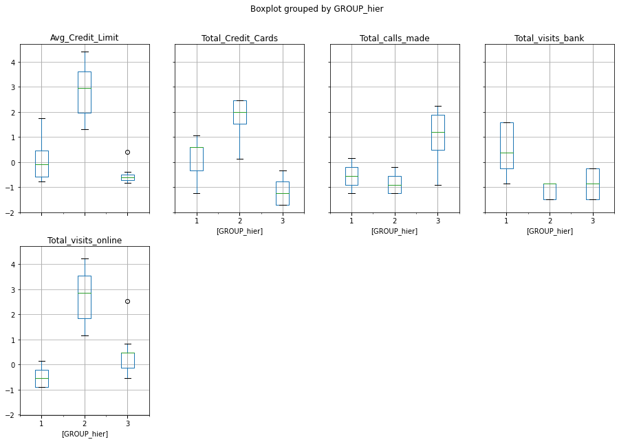

```python
data2Scaled.drop(columns=['GROUP']).boxplot(by='GROUP_hier', layout = (2,4),figsize=(15,10))
```

### Boxplot analysis:

There is still some overlap in values from group to group but it did not do a bad job of creatig these clusters. For the added information gain, I would probably stick to kmeans and have 4 clusters, personally, unless I was dealing with an extremely hefty amount of data and it was expensive to train.

### 4b. LINKAGE = "weighted"

```python
Z = linkage(data2Scaled, 'weighted', metric='euclidean')
Z.shape
```

```
(659, 4)
```

```python
Z
```

```
array([[4.64000000e+02, 4.97000000e+02, 0.00000000e+00, 2.00000000e+00],
       [2.50000000e+02, 3.61000000e+02, 0.00000000e+00, 2.00000000e+00],
       [4.25000000e+02, 4.55000000e+02, 0.00000000e+00, 2.00000000e+00],
       ...,
       [1.00000000e+00, 1.31200000e+03, 3.46883794e+00, 2.22000000e+02],
       [1.31500000e+03, 1.31600000e+03, 4.52707883e+00, 6.10000000e+02],
       [1.31400000e+03, 1.31700000e+03, 5.51213025e+00, 6.60000000e+02]])
```

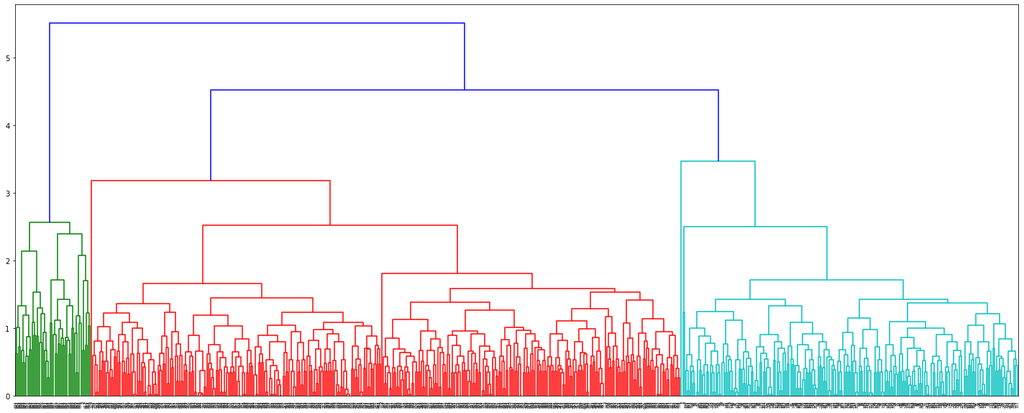

```python
plt.figure(figsize=(25, 10))
dendrogram(Z)
plt.show()
```

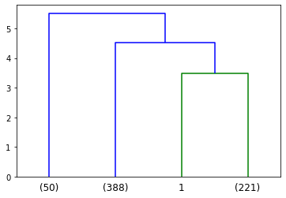

```python
dendrogram(
    Z,
    truncate_mode='lastp',  # show only the last p merged clusters
    p=4,  # show only the last p merged clusters
)
plt.show()
```

```python
max_d =4
clusters = fcluster(Z, max_d, criterion='maxclust')
clusters
```

```
array([2, 4, 2, 2, 1, 3, 1, 3, 3, 3, 3, 3, 3, 3, 3, 3, 3, 3, 3, 3, 3, 3,
       3, 3, 3, 3, 3, 3, 3, 3, 3, 3, 3, 3, 3, 3, 3, 3, 3, 3, 3, 3, 2, 3,
       3, 3, 3, 3, 3, 3, 3, 3, 3, 3, 3, 3, 3, 3, 3, 3, 3, 3, 3, 3, 3, 3,
       3, 3, 3, 3, 3, 3, 3, 3, 3, 3, 3, 3, 3, 3, 3, 3, 3, 3, 3, 3, 3, 3,
       3, 3, 3, 3, 3, 3, 3, 3, 3, 3, 3, 3, 3, 3, 3, 3, 3, 3, 3, 3, 3, 3,
       3, 3, 3, 3, 3, 3, 3, 3, 3, 3, 3, 3, 3, 3, 3, 3, 3, 3, 3, 3, 3, 3,
       3, 3, 3, 3, 3, 3, 3, 3, 3, 3, 3, 3, 3, 3, 3, 3, 3, 3, 3, 3, 3, 3,
       3, 3, 3, 3, 3, 3, 3, 3, 3, 3, 3, 3, 3, 3, 3, 3, 3, 3, 3, 3, 3, 3,
       3, 3, 3, 3, 3, 3, 3, 3, 3, 3, 3, 3, 3, 3, 3, 3, 3, 3, 3, 3, 3, 3,
       3, 3, 3, 3, 3, 3, 3, 3, 3, 3, 3, 3, 3, 3, 3, 3, 3, 3, 3, 3, 3, 3,
       3, 3, 3, 3, 3, 3, 3, 3, 2, 2, 2, 2, 2, 2, 2, 2, 2, 2, 2, 2, 2, 2,
       2, 2, 2, 2, 2, 2, 2, 2, 2, 2, 2, 2, 2, 2, 2, 2, 2, 2, 2, 2, 2, 2,
       2, 2, 2, 2, 2, 2, 2, 2, 2, 2, 2, 2, 2, 2, 2, 2, 2, 2, 2, 2, 2, 2,
       2, 2, 2, 2, 2, 2, 2, 2, 2, 2, 2, 2, 2, 2, 2, 2, 2, 2, 2, 2, 2, 2,
       2, 2, 2, 2, 2, 2, 2, 2, 2, 2, 2, 2, 2, 2, 2, 2, 2, 2, 2, 2, 2, 2,
```

[output cut: 16 more lines]

```python
#Append the clusters to the regular data and the scaled data
data["GROUP_hier_weighted"] = clusters
data2Scaled["GROUP_hier_weighted"] = clusters
print("Groups Assigned : \n")
data.head()
```

```
Groups Assigned :
```

|  | Sl_No | Customer Key | Avg_Credit_Limit | Total_Credit_Cards | Total_visits_bank | Total_visits_online | Total_calls_made | GROUP | GROUP_hier | GROUP_hier_weighted |
| --- | --- | --- | --- | --- | --- | --- | --- | --- | --- | --- |
| 0 | 1 | 87073 | 100000 | 2 | 1 | 1 | 0 | 2 | 1 | 2 |
| 1 | 2 | 38414 | 50000 | 3 | 0 | 10 | 9 | 1 | 3 | 4 |
| 2 | 3 | 17341 | 50000 | 7 | 1 | 3 | 4 | 2 | 1 | 2 |
| 3 | 4 | 40496 | 30000 | 5 | 1 | 1 | 4 | 2 | 1 | 2 |
| 4 | 5 | 47437 | 100000 | 6 | 0 | 12 | 3 | 0 | 2 | 1 |

```python
dataGrouped_hier_weighted = data.drop(columns=['GROUP', 'GROUP_hier']).groupby(['GROUP_hier_weighted'])
dataGrouped_hier_weighted.mean()
```

| GROUP_hier_weighted | Sl_No | Customer Key | Avg_Credit_Limit | Total_Credit_Cards | Total_visits_bank | Total_visits_online | Total_calls_made |
| --- | --- | --- | --- | --- | --- | --- | --- |
| 1 | 611.280000 | 56708.760000 | 141040.000000 | 8.740000 | 0.600000 | 10.900000 | 1.080000 |
| 2 | 416.296392 | 54919.360825 | 33667.525773 | 5.507732 | 3.481959 | 0.989691 | 2.010309 |
| 3 | 117.832579 | 55252.438914 | 12009.049774 | 2.393665 | 0.927602 | 3.533937 | 6.886878 |
| 4 | 2.000000 | 38414.000000 | 50000.000000 | 3.000000 | 0.000000 | 10.000000 | 9.000000 |

```
array([[<matplotlib.axes._subplots.AxesSubplot object at 0x147a2dd50>,
      dtype=object)
```

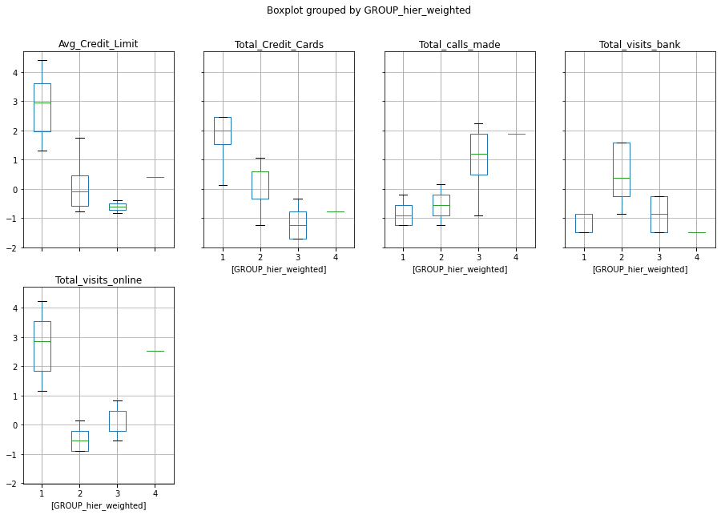

```python
data2Scaled.drop(columns=['GROUP', 'GROUP_hier']).boxplot(by='GROUP_hier_weighted', layout = (2,4),figsize=(15,10))
```

```python
data2Scaled.head()
```

|  | Avg_Credit_Limit | Total_Credit_Cards | Total_visits_bank | Total_visits_online | Total_calls_made | GROUP | GROUP_hier | GROUP_hier_weighted |
| --- | --- | --- | --- | --- | --- | --- | --- | --- |
| 0 | 1.740187 | -1.249225 | -0.860451 | -0.547490 | -1.251537 | 2 | 1 | 2 |
| 1 | 0.410293 | -0.787585 | -1.473731 | 2.520519 | 1.891859 | 1 | 3 | 4 |
| 2 | 0.410293 | 1.058973 | -0.860451 | 0.134290 | 0.145528 | 2 | 1 | 2 |
| 3 | -0.121665 | 0.135694 | -0.860451 | -0.547490 | 0.145528 | 2 | 1 | 2 |
| 4 | 1.740187 | 0.597334 | -1.473731 | 3.202298 | -0.203739 | 0 | 2 | 1 |

# 5. Silhouette Score

```python
from sklearn.metrics import silhouette_score

justData = data2Scaled.drop(columns=["GROUP", "GROUP_hier","GROUP_hier_weighted"])
score = silhouette_score(justData, data2Scaled["GROUP"])
print("For KMeans, silhouette score is {})".format(score))
```

```
For KMeans, silhouette score is 0.3556670619372605)
```

```python
score = silhouette_score(justData , data2Scaled["GROUP_hier"])
print("For Hierarchical Clustering with \"ward\", silhouette score is {})".format(score))
```

```
For Hierarchical Clustering with "ward", silhouette score is 0.5159338918998772)
```

```python
score = silhouette_score(justData , data2Scaled["GROUP_hier_weighted"])
print("For Hierarchical Clustering with \"weighted\", silhouette score is {})".format(score))
```

```
For Hierarchical Clustering with "weighted", silhouette score is 0.4790057590212698)
```

# 6-7. Compare models

Silhouette scores should be close to 1 in order to consider it the best fit. A number approaching 0 indicates that there is significant overlap and that the clustering is not that helpful in displaying, explaining or grouping the data points. A number approaching the negatives means the point is assigned to the wrong cluster so hopefully we don't get a model that bad at assigning points.

You can visually verify the overlap yourself if you look closely at the boxplots and compare across the groupings. When there is overlap for many values for many columns, its hard for the model to determine which group it belongs to or makes more sense to put in, therefore, the less overlap we have the better.

In terms of understanding the two different linkage options that were chosen:

- ’ward’ uses the Ward variance minimization algorithm. With ward I used 'distance' as the criterion for fcluster to choose the clusters. This means that the original observations in each flat cluster have no greater a cophenetic distance than t.
- 'weighted', aka WPGMA, is the proximity between two clusters as the arithmetic mean of all the proximities between the objects of one and the objects of the other. With this one I used 'maxclust' as the criterion for fclusters in order to choose a cluster for each point. This means the criteria is to find a minimum threshold r so that the cophenetic distance between any two original observations in the same flat cluster is no more than r and no more than t flat clusters are formed

"Ward" seemed to behave much better as it did a better job of deciding on a smaller set of clusters on its own. You can see above that I left max_d at 50 and it was still able to decide on 3 max clusters necessary. However, "weighted", did not do as well. I had to set max_d to 4 and enforce that only 4 clusters were made. If I left that number at 50, it was creating all 50 clusters and assigning the points to them which is probably not a good number of clusters for such a small dataset which would be a red flag and something to investigate.